# R Notebook

# Factor Analysis of boston housing data:

### 1. Load and check the data

```r
x <- read.table("bostonh.dat")
x[1:5,]
```

|  | V1 | V2 | V3 | V4 | V5 | V6 | V7 | V8 | V9 | V10 | V11 | V12 | V13 | V14 |
| --- | --- | --- | --- | --- | --- | --- | --- | --- | --- | --- | --- | --- | --- | --- |
| 1 | 0.00632 | 18 | 2.31 | 0 | 0.538 | 6.575 | 65.2 | 4.0900 | 1 | 296 | 15.3 | 396.90 | 4.98 | 24.0 |
| 2 | 0.02731 | 0 | 7.07 | 0 | 0.469 | 6.421 | 78.9 | 4.9671 | 2 | 242 | 17.8 | 396.90 | 9.14 | 21.6 |
| 3 | 0.02729 | 0 | 7.07 | 0 | 0.469 | 7.185 | 61.1 | 4.9671 | 2 | 242 | 17.8 | 392.83 | 4.03 | 34.7 |
| 4 | 0.03237 | 0 | 2.18 | 0 | 0.458 | 6.998 | 45.8 | 6.0622 | 3 | 222 | 18.7 | 394.63 | 2.94 | 33.4 |
| 5 | 0.06905 | 0 | 2.18 | 0 | 0.458 | 7.147 | 54.2 | 6.0622 | 3 | 222 | 18.7 | 396.90 | 5.33 | 36.2 |

### 2. Transforming the data

As per given in the book, we would transform the data to obtain the best interpretation by bringing the data on comparable scale.

```r
xt = x
xt[,1]  = log(boston[,1])
xt[,2] = boston[,2]/10
xt[,3]  = log(boston[,3])
xt[,5]  = log(boston[,5])
xt[,6]  = log(boston[,6])
xt[,7] = boston[,7]^2.7/10000
xt[,8]  = log(boston[,8])
xt[,9]  = log(boston[,9])
xt[,10]  = log(boston[,10])
xt[,11] = exp(0.4*boston[,11])/1000
xt[,12] = boston[,12]/100
xt[,13] = sqrt(boston[,13])
xt[,14] = log(boston[,14])
```

#### Removing the variable x4

```r
xt <- xt[,-c(4)]
colnames(x) = c("X1", "X2", "X3", "X5", "X6", "X7", "X8", "X9",
                   "X10", "X11", "X12", "X13", "X14")
xt[1:5,]
```

|  | V1 | V2 | V3 | V5 | V6 | V7 | V8 | V9 | V10 | V11 | V12 | V13 | V14 |
| --- | --- | --- | --- | --- | --- | --- | --- | --- | --- | --- | --- | --- | --- |
| 1 | -5.064036 | 1.8 | 0.8372475 | -0.6198967 | 1.883275 | 7.915321 | 1.408545 | 0.0000000 | 5.690359 | 0.4548647 | 3.9690 | 2.231591 | 3.178054 |
| 2 | -3.600502 | 0.0 | 1.9558605 | -0.7571525 | 1.859574 | 13.246706 | 1.602836 | 0.6931472 | 5.488938 | 1.2364504 | 3.9690 | 3.023243 | 3.072693 |
| 3 | -3.601235 | 0.0 | 1.9558605 | -0.7571525 | 1.971996 | 6.642190 | 1.602836 | 0.6931472 | 5.488938 | 1.2364504 | 3.9283 | 2.007486 | 3.546740 |
| 4 | -3.430523 | 0.0 | 0.7793249 | -0.7808861 | 1.945624 | 3.050260 | 1.802073 | 1.0986123 | 5.402677 | 1.7722408 | 3.9463 | 1.714643 | 3.508556 |
| 5 | -2.672924 | 0.0 | 0.7793249 | -0.7808861 | 1.966693 | 4.806158 | 1.802073 | 1.0986123 | 5.402677 | 1.7722408 | 3.9690 | 2.308679 | 3.589059 |

### 3. Standardizing the data

We are standardizing the dataset to bring the whole data on a same scale. Standardized data will have the mean equals to “zero” and standard deviation equals to “one”.

```r
scaled_data <- scale(xt)
scaled_data[1:5,]
```

```
             V1         V2         V3          V5        V6         V7        V8         V9        V10
[1,] -1.9812674  0.2845483 -1.7026586 -0.04899171 0.4576943 -0.4904973 0.4086998 -2.1348765 -0.6081371
[2,] -1.3043481 -0.4872402 -0.2629788 -0.73021967 0.2466931  0.0997219 0.7688007 -1.3425573 -1.1163074
[3,] -1.3046869 -0.4872402 -0.2629788 -0.73021967 1.2475534 -0.6314412 0.7688007 -1.3425573 -1.1163074
[4,] -1.2257286 -0.4872402 -1.7772063 -0.84801420 1.0127782 -1.0290913 1.1380675 -0.8790803 -1.3339352
[5,] -0.8753211 -0.4872402 -1.7772063 -0.84801420 1.2003437 -0.8347018 1.1380675 -0.8790803 -1.3339352
            V11       V12        V13        V14
[1,] -1.2427973 0.4406159 -1.2015004 0.35116465
[2,] -0.6697918 0.4406159 -0.3995573 0.09340624
[3,] -0.6697918 0.3960351 -1.4285190 1.25313328
[4,] -0.2769868 0.4157514 -1.7251690 1.15971885
[5,] -0.2769868 0.4406159 -1.1234103 1.35666532
```

### 4. Factor Analysis

For factor analysis of the data, first we will obtain the covariance matrix.

```r
cov <- cov(scaled_data)
cov[1:5,]
```

```
           V1         V2         V3         V5         V6         V7         V8         V9        V10
V1  1.0000000 -0.5170914  0.7395526  0.8069881 -0.3241580  0.6979521 -0.7439256  0.8389431  0.8099775
V2 -0.5170914  1.0000000 -0.6558980 -0.5685385  0.3094265 -0.5188573  0.5906552 -0.3506426 -0.3058923
V3  0.7395526 -0.6558980  1.0000000  0.7504627 -0.4295824  0.6584641 -0.7302965  0.5805329  0.6592854
V5  0.8069881 -0.5685385  0.7504627  1.0000000 -0.3182691  0.7820802 -0.8600183  0.6129483  0.6683072
V6 -0.3241580  0.3094265 -0.4295824 -0.3182691  1.0000000 -0.2787741  0.2807310 -0.2134283 -0.3064174
          V11        V12        V13        V14
V1  0.4539118 -0.4787552  0.6222761 -0.5672422
V2 -0.3500852  0.1755203 -0.4522499  0.3633445
V3  0.4546669 -0.3310505  0.6213791 -0.5538866
V5  0.3437191 -0.3793485  0.6094370 -0.5152507
V6 -0.3207940  0.1297350 -0.6394392  0.6104374
```

We are not sure about the how many factors we should consider for analysis. Hence, first we are calculating P-Values of factors.

```r
i = 1:8
for(a in i){
  print(factanal(scaled_data, factors = a, rotation = "none")$PVAL)
}
```

```
    objective
8.160483e-306
    objective
1.183931e-181
   objective
5.259249e-42
   objective
1.470479e-23
   objective
5.362778e-13
   objective
8.443136e-08
 objective
0.08347313
objective
0.7614501
```

As P-Values are beyonf 0.05 after factor 6, hence we can consider maximum 6 factors for analysis.

As given in the question, we are considering first 3 factors only. Let’s apply factor analysis on standardized data.

```r
load_mat <- factanal(scaled_data, factors = 3, rotation = "none")
```

#### Loadings

Displaying the loading corresponding to first 3 factos. Loadings explains the correlation between the factors and variables.

```r
load_mat$loadings
```

```
Loadings:
    Factor1 Factor2 Factor3
V1   0.930   0.165   0.109
V2  -0.582           0.289
V3   0.819          -0.139
V5   0.879          -0.273
V6  -0.445   0.531
V7   0.784          -0.352
V8  -0.829  -0.154   0.413
V9   0.796   0.308   0.404
V10  0.827   0.141   0.288
V11  0.505  -0.185   0.156
V12 -0.470          -0.162
V13  0.760  -0.506
V14 -0.694   0.590  -0.182

               Factor1 Factor2 Factor3
SS loadings      6.997   1.099   0.815
Proportion Var   0.538   0.085   0.063
Cumulative Var   0.538   0.623   0.685
```

#### Uniqueness of variables

Lesser the uniqueness of a variable, more the variance explained by common factors (F).

```r
load_mat$uniquenesses
```

```
        V1         V2         V3         V5         V6         V7         V8         V9        V10        V11
0.09647882 0.57692410 0.30891699 0.14402959 0.51894098 0.26168516 0.11789057 0.10830749 0.21366973 0.68642068
       V12        V13        V14
0.75210319 0.16668944 0.13684262
```

### 5. Plot

Plotting the two factors at a time.

```r
par(mfcol = c(2,2))
plot(load_mat$loadings[,1], load_mat$loadings[,2], type='n', xlab = "Factor1", ylab = "Factor2")
text(load_mat$loadings[,1], load_mat$loadings[,2], colnames(x))
```

```r
abline(h=0,v=0)
#Factor1 & Factor3
plot(load_mat$loadings[,1], load_mat$loadings[,3], type="n", xlab = "F1", ylab = "F3")
```

```r
text(load_mat$loadings[,1], load_mat$loadings[,3], colnames(x))
abline(h=0,v=0)
```

```r
#Factor2 can be interpreted as a "residential factor" - highly correlated with X6, and X13.
#Factor2 & Factor3
plot(load_mat$loadings[,2], load_mat$loadings[,3], type="n", xlab = "Factor2", ylab = "Factor3")
text(load_mat$loadings[,2], load_mat$loadings[,3], colnames(x))
```

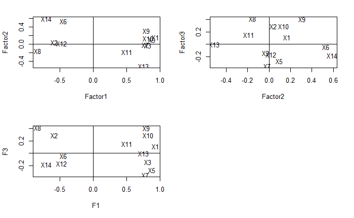

```r
abline(h=0,v=0)
```

### 6. Applying the varimax rotation

By applying the rotation to the above calculated factors, we obtain the new factors which explains the maximum variance amongst all the factors.

```r
load_mat_vm = factanal(scaled_data, factors = 3)
load_mat_vm$loadings
```

```
Loadings:
    Factor1 Factor2 Factor3
V1   0.553   0.724   0.271
V2  -0.584  -0.159  -0.238
V3   0.629   0.410   0.357
V5   0.790   0.413   0.247
V6  -0.165          -0.669
V7   0.766   0.253   0.295
V8  -0.872  -0.315  -0.152
V9   0.274   0.894   0.135
V10  0.349   0.766   0.277
V11  0.180   0.340   0.407
V12 -0.182  -0.391  -0.248
V13  0.407   0.259   0.775
V14 -0.211  -0.304  -0.852

               Factor1 Factor2 Factor3
SS loadings      3.515   2.872   2.525
Proportion Var   0.270   0.221   0.194
Cumulative Var   0.270   0.491   0.685
```

#### Uniqueness

Lesser the uniqueness of a variable, more the variance explained by common factors (F).

```r
load_mat_vm$uniquenesses
```

```
        V1         V2         V3         V5         V6         V7         V8         V9        V10        V11
0.09647882 0.57692410 0.30891699 0.14402959 0.51894098 0.26168516 0.11789057 0.10830749 0.21366973 0.68642068
       V12        V13        V14
0.75210319 0.16668944 0.13684262
```

#### Applying varimax rotation to the factors

```r
varimax(load_mat_vm$loadings)
```

```
$loadings

Loadings:
    Factor1 Factor2 Factor3
V1   0.553   0.724   0.270
V2  -0.584  -0.159  -0.238
V3   0.629   0.410   0.356
V5   0.790   0.413   0.247
V6  -0.165          -0.669
V7   0.766   0.253   0.295
V8  -0.872  -0.315  -0.151
V9   0.274   0.894   0.134
V10  0.350   0.766   0.277
V11  0.180   0.340   0.407
V12 -0.182  -0.391  -0.248
V13  0.407   0.259   0.775
V14 -0.212  -0.304  -0.852

               Factor1 Factor2 Factor3
SS loadings      3.516   2.872   2.523
Proportion Var   0.270   0.221   0.194
Cumulative Var   0.270   0.491   0.685

$rotmat
             [,1]          [,2]          [,3]
[1,] 9.999999e-01 -8.552316e-05 -0.0003188527
[2,] 8.548788e-05  1.000000e+00 -0.0001106569
[3,] 3.188621e-04  1.106296e-04  0.9999999430
```

## Interpretation

Factor1 is positively correlated with X1,X3,X5,X10 and negatively correlated with variable X8. it can be interpreted as quality of life since the increment in x1,x3,x5 and x10 relates with the Quality of life

Factor2 is highly correlated with X6 and X13. it can be interpreted as residential factors. the room and lower status highly suggest the impact of residential factors

# Principal component Analysis

### 1. Load and check the data

```r
x <- read.table("uscomp2.dat")
x[1:5,]
```

|  | V1 | V2 | V3 | V4 | V5 | V6 | V7 | V8 |
| --- | --- | --- | --- | --- | --- | --- | --- | --- |
| 1 | BellAtlantic | 19788 | 9084 | 10636 | 1092.9 | 2576.8 | 79.4 | Communication |
| 2 | ContinentalTelecom | 5074 | 2557 | 1892 | 239.9 | 578.3 | 21.9 | Communication |
| 3 | AmericanElectricPower | 13621 | 4848 | 4572 | 485.0 | 898.9 | 23.4 | Energy |
| 4 | BrooklynUnionGas | 1117 | 1038 | 478 | 59.7 | 91.7 | 3.8 | Energy |
| 5 | CentralIllinoisPublicService | 1633 | 701 | 679 | 74.3 | 135.9 | 2.8 | Energy |

There are 8 variables: V1 to V8. There are 6 numerical and 2 categorical variables, viz. V1 and V8. First variable V1 implies the name of a company and variable V8 implies the different sectors. We will omit both categorical variables to obtain the new dataset having only numerical variables.

#### Omit the categorical variables and convert the dataset to matrix form

```r
my_data <- subset(x, select = -c(V1,V8))
my_data <- data.matrix(my_data)
my_data[1:5,]
```

```
     V2   V3    V4     V5     V6   V7
1 19788 9084 10636 1092.9 2576.8 79.4
2  5074 2557  1892  239.9  578.3 21.9
3 13621 4848  4572  485.0  898.9 23.4
4  1117 1038   478   59.7   91.7  3.8
5  1633  701   679   74.3  135.9  2.8
```

### 2. Standardize the data

We are standardizing the dataset to bring the whole data on a same scale. Standardized data will have the mean equals to “zero” and standard deviation equals to “one”.

```r
scaled_data <- as.data.frame(scale(my_data))
scaled_data[1:5,]
```

|  | V2 | V3 | V4 | V5 | V6 | V7 |
| --- | --- | --- | --- | --- | --- | --- |
| 1 | 1.51226328 | 0.69965281 | 0.6516764 | 1.10801280 | 1.8049052 | 0.6480590 |
| 2 | -0.09463275 | -0.23122875 | -0.1218863 | 0.03771848 | 0.1471269 | -0.2433557 |
| 3 | 0.83877356 | 0.09551396 | 0.1152075 | 0.34525557 | 0.4130683 | -0.2201015 |
| 4 | -0.52677136 | -0.44786872 | -0.2469798 | -0.18838591 | -0.2565132 | -0.5239576 |
| 5 | -0.47041970 | -0.49593170 | -0.2291977 | -0.17006668 | -0.2198488 | -0.5394605 |

### 3. PCA

Principle Componenet Analysis is a method of extracting important variables in form of components from a large set of variables available in a data set. It extracts low dimensional set of features from a high dimensional data set with a motive to capture as much information as possible. The steps to obtain principle components are described below.

#### 3.1 Obtain the eigen-values and eigen-vectors of covariance matrix of original dataset

```r
e = eigen(cov(scaled_data))
e$vectors <- -1*e$vectors
e$vectors
```

```
          [,1]         [,2]       [,3]        [,4]         [,5]         [,6]
[1,] 0.3403606 -0.849198673  0.3391827  0.20497702  0.076946275 -0.005924747
[2,] 0.4232888 -0.170126491 -0.3792634 -0.78330229 -0.005758847 -0.185599579
[3,] 0.4335086  0.190169817  0.1922844  0.07085296 -0.843701012  0.148596462
[4,] 0.4196585  0.363694662  0.3239922  0.15561733  0.260663380 -0.703192629
[5,] 0.4278932  0.285277688  0.2673164 -0.12149577  0.452330852  0.666859461
[6,] 0.3972980  0.009842003 -0.7264380  0.54810932  0.098316381  0.065233205
```

#### Variance explained by PCs

```r
100*e$values/sum(e$values)
```

```
[1] 83.9775248  8.6147241  5.9829869  0.8250699  0.4851806  0.1145137
```

#### 3.2 Principle Components

Priciple components (PC) are obtained by directly multiplying the standardize data with eigenvectors.

```r
y <- as.matrix(scaled_data)%*%e$vectors
y[1:5,]
```

```
        [,1]       [,2]      [,3]         [,4]        [,5]         [,6]
1  2.5881436 -0.3550566 0.7435815  0.116457629  0.73146132  0.424768390
2 -0.2008258  0.1498160 0.2604948  0.007697256  0.14934156  0.081079532
3  0.6100516 -0.4653853 0.6525952 -0.011822157  0.22198919  0.012741934
4 -0.8729232  0.3297105 0.1947151 -0.059995580 -0.04622459 -0.023221215
5 -0.8491622  0.3103847 0.2624745 -0.019638077 -0.03677907 -0.001435512
```

The above six columns represents the Pricipal Components PC1 to PC6. As we know, PC1 retains the maximum variance and so on.

## B. Plot

First change the labels of different sectors to make the convenient representation of the datapoints on scatter-plot.

```r
v8 <- x$V8
v8 <- as.character(v8)
v8[grepl('Manufacturing', v8)] <- 'M'
v8[grepl('Communication', v8)] <- 'H'
v8[grepl('HiTech', v8)] <- 'H'
v8[grepl('Energy', v8)] <- 'E'
v8[grepl('Finance', v8)] <- 'F'
v8[grepl('Retail', v8)] <- 'R'
v8[grepl('Medical', v8)] <- '*'
v8[grepl('Other', v8)] <- '*'
v8[grepl('Transportation', v8)] <- '*'
v8
```

```
 [1] "H" "H" "E" "E" "E" "E" "E" "E" "E" "E" "E" "E" "E" "E" "E" "E" "E" "F" "F" "F" "F" "F" "F" "F" "F" "F" "F"
[28] "F" "F" "F" "F" "F" "F" "F" "H" "H" "H" "H" "H" "H" "H" "H" "M" "M" "M" "M" "M" "M" "M" "M" "M" "M" "*" "*"
[55] "*" "*" "*" "*" "*" "*" "*" "*" "*" "R" "R" "R" "R" "R" "R" "R" "R" "R" "R" "*" "*" "*" "*" "*" "*"
```

#### Scatter-plot of all observations with respect to PC1 and PC2

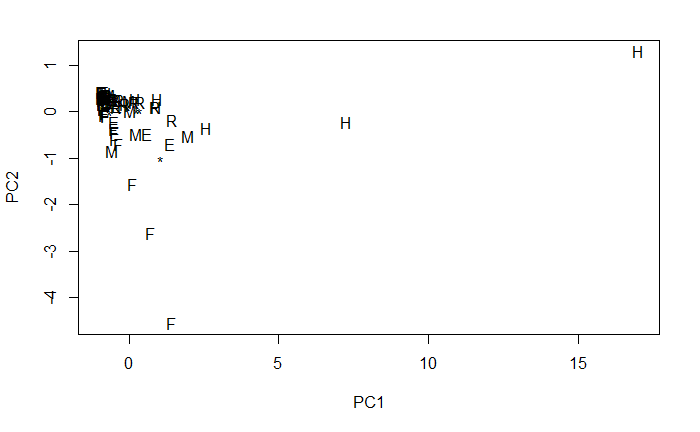

```r
plot(y[,1], y[,2], pch = as.character(v8),
     xlab = "PC1", ylab = "PC2")
```

## C Removing the outliers and performing PCA on new dataset

```r
which.max(y[,1])
```

```
40
40
```

```r
my_data <- my_data[-c(40),]
y <- y[-c(40),]
```

```r
which.max(y[,1])
```

```
38
38
```

```r
my_new_data <- my_data[-c(38),]
my_new_data[36:41,]
```

```
     V2   V3   V4    V5    V6   V7
36 6914 7029 7957 400.6 754.7 87.3
37  430 1155 1045  55.7  70.8 22.5
39 5769 6571 9462 482.0 792.0 83.0
41 3940 4317 3940 315.2 566.3 62.0
42  478  672  866  67.1 101.6  5.4
43 1093 1679 1070 100.9 164.5 20.8
```

Here, we have removed two rightmost outliers on above scatter-plot. Now, we will again follow the above process to get principal components for the new data (data after removing outliers).

### 1. Standardize the data

```r
scaled_new_data <- scale(my_new_data)
scaled_new_data[1:5,]
```

```
             V2         V3         V4         V5         V6         V7
1  2.0598201600  1.5387564  4.2666523  4.4238488  6.0015412  1.2738656
2  0.0008396006 -0.1885279  0.1005078  0.6240029  0.8757465 -0.1919174
3  1.1968506677  0.4177550  1.3774139  1.7158461  1.6980281 -0.1536796
4 -0.5528770008 -0.5905112 -0.5732031 -0.1787312 -0.3722954 -0.6533205
5 -0.4806713485 -0.6796938 -0.4774352 -0.1136928 -0.2589303 -0.6788123
```

### 2. Obtain the eigen-values and eigen-vectors of covariance matrix of original dataset

```r
e_new = eigen(cov(scaled_new_data))
e_new$vectors[,2] <- -1*e_new$vectors[,2]
e_new$vectors[1:6,]
```

```
          [,1]         [,2]        [,3]        [,4]       [,5]        [,6]
[1,] 0.2631088 -0.407582637  0.79976727  0.06745406 -0.3327455 -0.09875675
[2,] 0.4384103 -0.407145234 -0.16156743  0.50933690  0.4407480  0.40279303
[3,] 0.5004802 -0.002849962  0.03502370 -0.80132128  0.2644876  0.19030301
[4,] 0.3306406  0.623458899  0.08036057  0.19205259 -0.4263242  0.52619528
[5,] 0.4430285  0.450107084  0.12341464  0.23789161  0.3354368 -0.64559114
[6,] 0.4271911 -0.277134706 -0.55798981 -0.02081970 -0.5751502 -0.31324152
```

```r
e_new$values
```

```
[1] 3.19145976 1.53505124 0.79082557 0.29231546 0.14894657 0.04140138
```

```r
100*e_new$values/sum(e_new$values)
```

```
[1] 53.1909961 25.5841874 13.1804262  4.8719244  2.4824429  0.6900231
```

### 3. Principle Components

```r
y_new <- as.matrix(scaled_new_data)%*%e_new$vectors
y_new[1:5,]
```

```
        [,1]      [,2]        [,3]        [,4]       [,5]         [,6]
1  8.0176804 3.6281877  1.93357481 -0.24546419 0.51576462 -0.717425069
2  0.4801864 0.9125365  0.29996476  0.15566315 0.08132177 -0.233803962
3  2.4413710 1.2148159  1.37114809 -0.07356175 0.07665022  0.166974810
4 -1.1943558 0.3694539 -0.06260473  0.01196710 0.09916879  0.058614456
5 -1.1056881 0.4747014  0.04634778 -0.06533710 0.08612611  0.002806977
```